# R4DS Ch 27 exercises

Chris Sirico

10/25/2017

## 27.2.1 Exercises

1. **Create a new notebook using *File > New File > R Notebook*. Read the instructions. Practice running the chunks. Verify that you can modify the code, re-run it, and see modified output.**

   Did it. Learned Cmd+Opt+I makes a new chunk. Cmd+Return runs the current line of code and Cmd+Shift+Return runs the whole chunk. Neat. Notebooks auto-create html files whether or not you knit to preview. Not so w/ normal RMDs.
2. **Create a new R Markdown document with *File > New File > R Markdown…* Knit it by clicking the appropriate button. Knit it by using the appropriate keyboard short cut. Verify that you can modify the input and see the output update.**

   Cmd+~ switches between preview and editor windows. Along those lines ctrl+tab (mac) switches between documents in the script window. Nice to know.
3. **Compare and contrast the R notebook and R markdown files you created above. How are the outputs similar? How are they different? How are the inputs similar? How are they different? What happens if you copy the YAML header from one to the other?**

   Notebook doesn’t show the header. Vanilla RMD knit does. output:html_document vs output:html_notebook makes the difference. Changing that field of the YAML header tells R whether to auto-generate html or not.
4. **Create one new R Markdown document for each of the three built-in formats: HTML, PDF and Word. Knit each of the three documents. How does the output differ? How does the input differ? (You may need to install LaTeX in order to build the PDF output — RStudio will prompt you if this is necessary.)**

   Output is predictably in each of the three filetypes.

## 27.3.1 Exercises

1. **Practice what you’ve learned by creating a brief CV. The title should be your name, and you should include headings for (at least) education or employment. Each of the sections should include a bulleted list of jobs/degrees. Highlight the year in bold.**

# Chris Sirico, Marker-Downer

## Education

   - Coursera
   - Liberal arts university, **2005 – 2008**
   - Hard knocks
2. **Using the R Markdown quick reference, figure out how to:**

Add [^1]

Add a horizontal rule.

> Add a block quote.
3. **Copy and paste the contents of `diamond-sizes.Rmd` from https://github.com/hadley/r4ds/tree/master/rmarkdown in to a local R markdown document. Check that you can run it, then add text after the frequency polygon that describes its most striking features.**

   👍

## 27.4.7 Exercises

1. **Add a section that explores how diamond sizes vary by cut, colour, and clarity. Assume you’re writing a report for someone who doesn’t know R, and instead of setting echo = FALSE on each chunk, set a global option.**

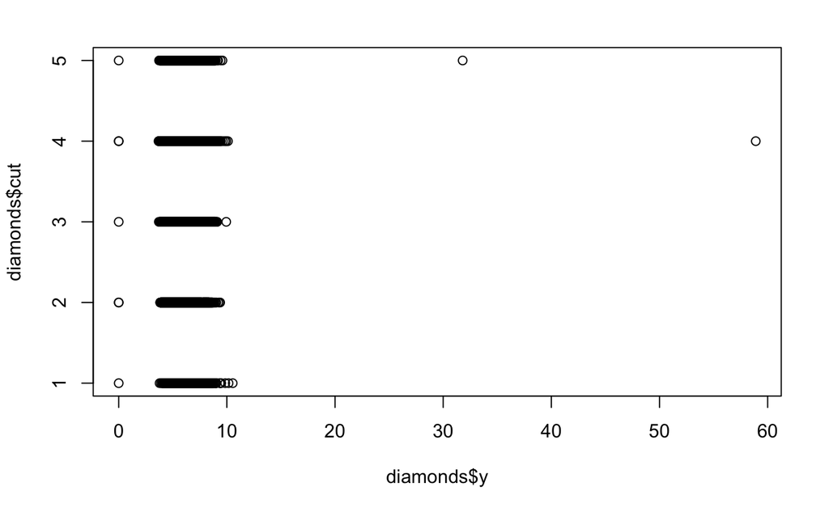

2. **Download diamond-sizes.Rmd from https://github.com/hadley/r4ds/tree/master/rmarkdown. Add a section that describes the largest 20 diamonds, including a table that displays their most important attributes.**

A synopsis of the 20 largest diamonds:

```
   Min. 1st Qu.  Median    Mean 3rd Qu.    Max.
  8.970   9.220   9.470   9.556   9.873  10.540
```

These babies are about a centimeter in diameter! Daggum.

3. **Modify diamonds-sizes.Rmd to use comma() to produce nicely formatted output. Also include the percentage of diamonds that are larger than 2.5 carats.**

0.23 percent of diamonds are larger than 2.5 carat.

4. **Set up a network of chunks where d depends on c and b, and both b and c depend on a. Have each chunk print lubridate::now(), set cache = TRUE, then verify your understanding of caching.**

```
[1] "2017-10-25 19:12:09 EDT"
```

```
[1] "2017-10-25 19:12:05 EDT"
```

```
[1] "2017-10-25 19:36:41 EDT"
```

```
[1] "2017-10-25 19:12:18 EDT"
```

[^1]: a footnote.